# Risk Factor Analysis

## Outcome Variable

**Outcome Variable:** ever_stunted

## Predictor Variables

**Intervention Variable:** vagbrth

**Adjustment Set:**

unadjusted

## Stratifying Variables

The analysis was stratified on these variable(s):

- agecat
- studyid

The following strata were considered:

- agecat: 12 months, studyid: ki1000108-CMC-V-BCS-2002
- agecat: 12 months, studyid: ki1000108-IRC
- agecat: 12 months, studyid: ki1017093b-PROVIDE
- agecat: 12 months, studyid: ki1017093c-NIH-Crypto
- agecat: 12 months, studyid: ki1066203-TanzaniaChild2
- agecat: 12 months, studyid: ki1126311-ZVITAMBO
- agecat: 18 months, studyid: ki1000108-CMC-V-BCS-2002
- agecat: 18 months, studyid: ki1000108-IRC
- agecat: 18 months, studyid: ki1017093b-PROVIDE
- agecat: 18 months, studyid: ki1017093c-NIH-Crypto
- agecat: 18 months, studyid: ki1066203-TanzaniaChild2
- agecat: 18 months, studyid: ki1126311-ZVITAMBO
- agecat: 24 months, studyid: ki1000108-CMC-V-BCS-2002
- agecat: 24 months, studyid: ki1000108-IRC
- agecat: 24 months, studyid: ki1017093b-PROVIDE
- agecat: 24 months, studyid: ki1017093c-NIH-Crypto
- agecat: 24 months, studyid: ki1066203-TanzaniaChild2
- agecat: 24 months, studyid: ki1126311-ZVITAMBO
- agecat: 3 months, studyid: ki1000108-CMC-V-BCS-2002
- agecat: 3 months, studyid: ki1000108-IRC
- agecat: 3 months, studyid: ki1017093b-PROVIDE
- agecat: 3 months, studyid: ki1017093c-NIH-Crypto
- agecat: 3 months, studyid: ki1066203-TanzaniaChild2
- agecat: 3 months, studyid: ki1126311-ZVITAMBO
- agecat: 6 months, studyid: ki1000108-CMC-V-BCS-2002
- agecat: 6 months, studyid: ki1000108-IRC
- agecat: 6 months, studyid: ki1017093b-PROVIDE
- agecat: 6 months, studyid: ki1017093c-NIH-Crypto
- agecat: 6 months, studyid: ki1066203-TanzaniaChild2
- agecat: 6 months, studyid: ki1126311-ZVITAMBO

### Dropped Strata

Some strata were dropped due to rare outcomes:

- agecat: 18 months, studyid: ki1000108-CMC-V-BCS-2002
- agecat: 24 months, studyid: ki1000108-CMC-V-BCS-2002

## Methods Detail

We’re interested in the causal parameters $E[Y_a]$ for all values of $a \in \mathcal{A}$. These parameters represent the mean outcome if, possibly contrary to fact, we intervened to set all units to have $A=a$. Under the randomization and positivity assumptions, these are identified by the statistical parameters $\psi_a=E_W[E_{Y|A,W}(Y|A=a,W)]$. In addition, we’re interested in the mean of $Y$, $E[Y]$ under no intervention (the observed mean). We will estimate these parameters by using SuperLearner to fit the relevant likelihood factors – $E_{Y|A,W}(Y|A=a,W)$ and $p(A=a|W)$, and then updating our likelihood fit using a joint TMLE.

For unadjusted analyses ($W=\{\}$), initial likelihoods were estimated using Lrnr_glm to estimate the simple $E(Y|A)$ and Lrnr_mean to estimate $p(A)$. For adjusted analyses, a small library containing Lrnr_glmnet, Lrnr_xgboost, and Lrnr_mean was used.

Having estimated these parameters, we will then use the delta method to estimate relative risks and attributable risks relative to a prespecified baseline level of $A$.

# Results Detail

## Results Plots

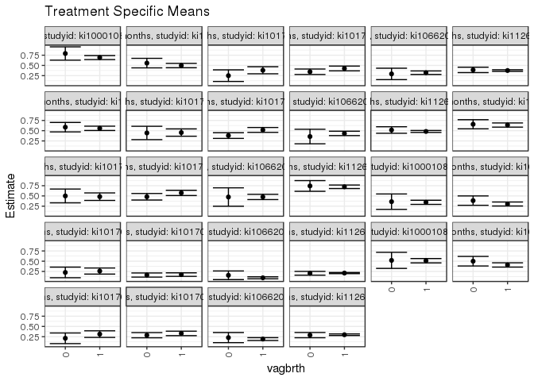

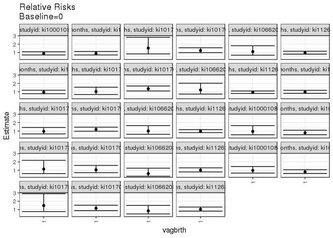

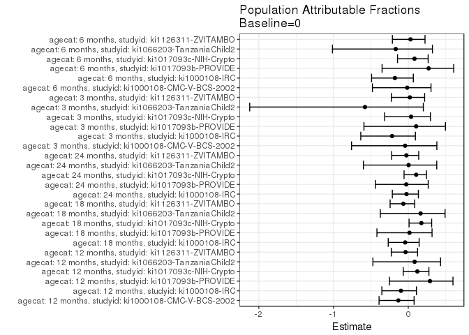

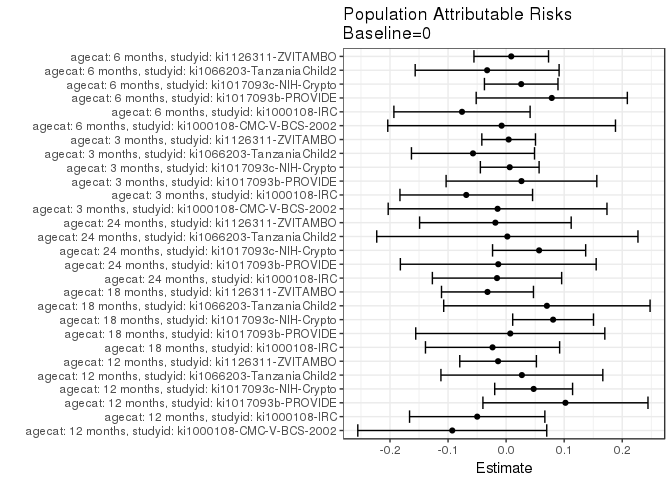

## Data Summary

| agecat | studyid | A | n | nA | nAY0 | nAY1 |
| --- | --- | --- | --- | --- | --- | --- |
| 3 months | ki1000108-CMC-V-BCS-2002 | 0 | 362 | 25 | 16 | 9 |
| 3 months | ki1000108-CMC-V-BCS-2002 | 1 | 362 | 337 | 221 | 116 |
| 3 months | ki1000108-IRC | 0 | 410 | 70 | 43 | 27 |
| 3 months | ki1000108-IRC | 1 | 410 | 340 | 237 | 103 |
| 3 months | ki1017093b-PROVIDE | 0 | 175 | 40 | 31 | 9 |
| 3 months | ki1017093b-PROVIDE | 1 | 175 | 135 | 100 | 35 |
| 3 months | ki1017093c-NIH-Crypto | 0 | 500 | 204 | 171 | 33 |
| 3 months | ki1017093c-NIH-Crypto | 1 | 500 | 296 | 245 | 51 |
| 3 months | ki1066203-TanzaniaChild2 | 0 | 599 | 45 | 38 | 7 |
| 3 months | ki1066203-TanzaniaChild2 | 1 | 599 | 554 | 502 | 52 |
| 3 months | ki1126311-ZVITAMBO | 0 | 3471 | 293 | 233 | 60 |
| 3 months | ki1126311-ZVITAMBO | 1 | 3471 | 3178 | 2512 | 666 |
| 6 months | ki1000108-CMC-V-BCS-2002 | 0 | 367 | 25 | 12 | 13 |
| 6 months | ki1000108-CMC-V-BCS-2002 | 1 | 367 | 342 | 167 | 175 |
| 6 months | ki1000108-IRC | 0 | 408 | 70 | 35 | 35 |
| 6 months | ki1000108-IRC | 1 | 408 | 338 | 200 | 138 |
| 6 months | ki1017093b-PROVIDE | 0 | 166 | 38 | 30 | 8 |
| 6 months | ki1017093b-PROVIDE | 1 | 166 | 128 | 88 | 40 |
| 6 months | ki1017093c-NIH-Crypto | 0 | 478 | 196 | 140 | 56 |
| 6 months | ki1017093c-NIH-Crypto | 1 | 478 | 282 | 189 | 93 |
| 6 months | ki1066203-TanzaniaChild2 | 0 | 555 | 44 | 34 | 10 |
| 6 months | ki1066203-TanzaniaChild2 | 1 | 555 | 511 | 413 | 98 |
| 6 months | ki1126311-ZVITAMBO | 0 | 2271 | 191 | 136 | 55 |
| 6 months | ki1126311-ZVITAMBO | 1 | 2271 | 2080 | 1461 | 619 |
| 12 months | ki1000108-CMC-V-BCS-2002 | 0 | 372 | 24 | 5 | 19 |
| 12 months | ki1000108-CMC-V-BCS-2002 | 1 | 372 | 348 | 107 | 241 |
| 12 months | ki1000108-IRC | 0 | 408 | 70 | 31 | 39 |
| 12 months | ki1000108-IRC | 1 | 408 | 338 | 170 | 168 |
| 12 months | ki1017093b-PROVIDE | 0 | 159 | 36 | 27 | 9 |
| 12 months | ki1017093b-PROVIDE | 1 | 159 | 123 | 76 | 47 |
| 12 months | ki1017093c-NIH-Crypto | 0 | 471 | 194 | 127 | 67 |
| 12 months | ki1017093c-NIH-Crypto | 1 | 471 | 277 | 159 | 118 |
| 12 months | ki1066203-TanzaniaChild2 | 0 | 494 | 41 | 29 | 12 |
| 12 months | ki1066203-TanzaniaChild2 | 1 | 494 | 453 | 307 | 146 |
| 12 months | ki1126311-ZVITAMBO | 0 | 2525 | 210 | 128 | 82 |
| 12 months | ki1126311-ZVITAMBO | 1 | 2525 | 2315 | 1446 | 869 |
| 18 months | ki1000108-CMC-V-BCS-2002 | 0 | 373 | 25 | 4 | 21 |
| 18 months | ki1000108-CMC-V-BCS-2002 | 1 | 373 | 348 | 53 | 295 |
| 18 months | ki1000108-IRC | 0 | 409 | 70 | 29 | 41 |
| 18 months | ki1000108-IRC | 1 | 409 | 339 | 150 | 189 |
| 18 months | ki1017093b-PROVIDE | 0 | 155 | 36 | 20 | 16 |
| 18 months | ki1017093b-PROVIDE | 1 | 155 | 119 | 65 | 54 |
| 18 months | ki1017093c-NIH-Crypto | 0 | 459 | 189 | 117 | 72 |
| 18 months | ki1017093c-NIH-Crypto | 1 | 459 | 270 | 130 | 140 |
| 18 months | ki1066203-TanzaniaChild2 | 0 | 358 | 28 | 18 | 10 |
| 18 months | ki1066203-TanzaniaChild2 | 1 | 358 | 330 | 187 | 143 |
| 18 months | ki1126311-ZVITAMBO | 0 | 1842 | 153 | 74 | 79 |
| 18 months | ki1126311-ZVITAMBO | 1 | 1842 | 1689 | 876 | 813 |
| 24 months | ki1000108-CMC-V-BCS-2002 | 0 | 373 | 25 | 3 | 22 |
| 24 months | ki1000108-CMC-V-BCS-2002 | 1 | 373 | 348 | 25 | 323 |
| 24 months | ki1000108-IRC | 0 | 410 | 70 | 24 | 46 |
| 24 months | ki1000108-IRC | 1 | 410 | 340 | 123 | 217 |
| 24 months | ki1017093b-PROVIDE | 0 | 148 | 34 | 17 | 17 |
| 24 months | ki1017093b-PROVIDE | 1 | 148 | 114 | 59 | 55 |
| 24 months | ki1017093c-NIH-Crypto | 0 | 380 | 150 | 78 | 72 |
| 24 months | ki1017093c-NIH-Crypto | 1 | 380 | 230 | 98 | 132 |
| 24 months | ki1066203-TanzaniaChild2 | 0 | 248 | 19 | 10 | 9 |
| 24 months | ki1066203-TanzaniaChild2 | 1 | 248 | 229 | 120 | 109 |
| 24 months | ki1126311-ZVITAMBO | 0 | 463 | 43 | 11 | 32 |
| 24 months | ki1126311-ZVITAMBO | 1 | 463 | 420 | 116 | 304 |

## Results Table

### Parameter: TSM

| agecat | studyid | intervention_level | baseline_level | estimate | ci_lower | ci_upper |
| --- | --- | --- | --- | --- | --- | --- |
| 3 months | ki1000108-CMC-V-BCS-2002 | 0 | NA | 0.3600000 | 0.1715830 | 0.5484170 |
| 3 months | ki1000108-CMC-V-BCS-2002 | 1 | NA | 0.3442136 | 0.2934177 | 0.3950096 |
| 3 months | ki1000108-IRC | 0 | NA | 0.3857143 | 0.2715455 | 0.4998831 |
| 3 months | ki1000108-IRC | 1 | NA | 0.3029412 | 0.2540362 | 0.3518461 |
| 3 months | ki1017093b-PROVIDE | 0 | NA | 0.2250000 | 0.0952209 | 0.3547791 |
| 3 months | ki1017093b-PROVIDE | 1 | NA | 0.2592593 | 0.1851238 | 0.3333947 |
| 3 months | ki1017093c-NIH-Crypto | 0 | NA | 0.1617647 | 0.1111831 | 0.2123463 |
| 3 months | ki1017093c-NIH-Crypto | 1 | NA | 0.1722973 | 0.1292334 | 0.2153612 |
| 3 months | ki1066203-TanzaniaChild2 | 0 | NA | 0.1555556 | 0.0495733 | 0.2615378 |
| 3 months | ki1066203-TanzaniaChild2 | 1 | NA | 0.0938628 | 0.0695576 | 0.1181680 |
| 3 months | ki1126311-ZVITAMBO | 0 | NA | 0.2047782 | 0.1585653 | 0.2509910 |
| 3 months | ki1126311-ZVITAMBO | 1 | NA | 0.2095658 | 0.1954135 | 0.2237181 |
| 6 months | ki1000108-CMC-V-BCS-2002 | 0 | NA | 0.5200000 | 0.3238931 | 0.7161069 |
| 6 months | ki1000108-CMC-V-BCS-2002 | 1 | NA | 0.5116959 | 0.4586467 | 0.5647451 |
| 6 months | ki1000108-IRC | 0 | NA | 0.5000000 | 0.3827259 | 0.6172741 |
| 6 months | ki1000108-IRC | 1 | NA | 0.4082840 | 0.3558201 | 0.4607479 |
| 6 months | ki1017093b-PROVIDE | 0 | NA | 0.2105263 | 0.0805122 | 0.3405404 |
| 6 months | ki1017093b-PROVIDE | 1 | NA | 0.3125000 | 0.2319591 | 0.3930409 |
| 6 months | ki1017093c-NIH-Crypto | 0 | NA | 0.2857143 | 0.2224036 | 0.3490249 |
| 6 months | ki1017093c-NIH-Crypto | 1 | NA | 0.3297872 | 0.2748583 | 0.3847162 |
| 6 months | ki1066203-TanzaniaChild2 | 0 | NA | 0.2272727 | 0.1033360 | 0.3512095 |
| 6 months | ki1066203-TanzaniaChild2 | 1 | NA | 0.1917808 | 0.1576146 | 0.2259470 |
| 6 months | ki1126311-ZVITAMBO | 0 | NA | 0.2879581 | 0.2237271 | 0.3521891 |
| 6 months | ki1126311-ZVITAMBO | 1 | NA | 0.2975962 | 0.2779436 | 0.3172487 |
| 12 months | ki1000108-CMC-V-BCS-2002 | 0 | NA | 0.7916667 | 0.6289704 | 0.9543629 |
| 12 months | ki1000108-CMC-V-BCS-2002 | 1 | NA | 0.6925287 | 0.6439815 | 0.7410759 |
| 12 months | ki1000108-IRC | 0 | NA | 0.5571429 | 0.4406372 | 0.6736485 |
| 12 months | ki1000108-IRC | 1 | NA | 0.4970414 | 0.4436729 | 0.5504099 |
| 12 months | ki1017093b-PROVIDE | 0 | NA | 0.2500000 | 0.1081049 | 0.3918951 |
| 12 months | ki1017093b-PROVIDE | 1 | NA | 0.3821138 | 0.2959716 | 0.4682561 |
| 12 months | ki1017093c-NIH-Crypto | 0 | NA | 0.3453608 | 0.2783806 | 0.4123410 |
| 12 months | ki1017093c-NIH-Crypto | 1 | NA | 0.4259928 | 0.3676980 | 0.4842875 |
| 12 months | ki1066203-TanzaniaChild2 | 0 | NA | 0.2926829 | 0.1532704 | 0.4320955 |
| 12 months | ki1066203-TanzaniaChild2 | 1 | NA | 0.3222958 | 0.2792147 | 0.3653769 |
| 12 months | ki1126311-ZVITAMBO | 0 | NA | 0.3904762 | 0.3244803 | 0.4564721 |
| 12 months | ki1126311-ZVITAMBO | 1 | NA | 0.3753780 | 0.3556491 | 0.3951068 |
| 18 months | ki1000108-IRC | 0 | NA | 0.5857143 | 0.4701766 | 0.7012519 |
| 18 months | ki1000108-IRC | 1 | NA | 0.5575221 | 0.5045855 | 0.6104588 |
| 18 months | ki1017093b-PROVIDE | 0 | NA | 0.4444444 | 0.2815993 | 0.6072896 |
| 18 months | ki1017093b-PROVIDE | 1 | NA | 0.4537815 | 0.3640414 | 0.5435216 |
| 18 months | ki1017093c-NIH-Crypto | 0 | NA | 0.3809524 | 0.3116436 | 0.4502611 |
| 18 months | ki1017093c-NIH-Crypto | 1 | NA | 0.5185185 | 0.4588546 | 0.5781824 |
| 18 months | ki1066203-TanzaniaChild2 | 0 | NA | 0.3571429 | 0.1794153 | 0.5348704 |
| 18 months | ki1066203-TanzaniaChild2 | 1 | NA | 0.4333333 | 0.3797939 | 0.4868727 |
| 18 months | ki1126311-ZVITAMBO | 0 | NA | 0.5163399 | 0.4371338 | 0.5955459 |
| 18 months | ki1126311-ZVITAMBO | 1 | NA | 0.4813499 | 0.4575147 | 0.5051851 |
| 24 months | ki1000108-IRC | 0 | NA | 0.6571429 | 0.5458119 | 0.7684738 |
| 24 months | ki1000108-IRC | 1 | NA | 0.6382353 | 0.5870975 | 0.6893731 |
| 24 months | ki1017093b-PROVIDE | 0 | NA | 0.5000000 | 0.3313638 | 0.6686362 |
| 24 months | ki1017093b-PROVIDE | 1 | NA | 0.4824561 | 0.3904175 | 0.5744948 |
| 24 months | ki1017093c-NIH-Crypto | 0 | NA | 0.4800000 | 0.3999434 | 0.5600566 |
| 24 months | ki1017093c-NIH-Crypto | 1 | NA | 0.5739130 | 0.5099206 | 0.6379055 |
| 24 months | ki1066203-TanzaniaChild2 | 0 | NA | 0.4736842 | 0.2487185 | 0.6986499 |
| 24 months | ki1066203-TanzaniaChild2 | 1 | NA | 0.4759825 | 0.4111674 | 0.5407976 |
| 24 months | ki1126311-ZVITAMBO | 0 | NA | 0.7441860 | 0.6136332 | 0.8747389 |
| 24 months | ki1126311-ZVITAMBO | 1 | NA | 0.7238095 | 0.6810031 | 0.7666160 |

### Parameter: E(Y)

| agecat | studyid | intervention_level | baseline_level | estimate | ci_lower | ci_upper |
| --- | --- | --- | --- | --- | --- | --- |
| 3 months | ki1000108-CMC-V-BCS-2002 | NA | NA | 0.3453039 | 0.3448910 | 0.3457168 |
| 3 months | ki1000108-IRC | NA | NA | 0.3170732 | 0.3140547 | 0.3200916 |
| 3 months | ki1017093b-PROVIDE | NA | NA | 0.2514286 | 0.2492911 | 0.2535661 |
| 3 months | ki1017093c-NIH-Crypto | NA | NA | 0.1680000 | 0.1675458 | 0.1684542 |
| 3 months | ki1066203-TanzaniaChild2 | NA | NA | 0.0984975 | 0.0971941 | 0.0998009 |
| 3 months | ki1126311-ZVITAMBO | NA | NA | 0.2091616 | 0.2091173 | 0.2092059 |
| 6 months | ki1000108-CMC-V-BCS-2002 | NA | NA | 0.5122616 | 0.5120472 | 0.5124759 |
| 6 months | ki1000108-IRC | NA | NA | 0.4240196 | 0.4206604 | 0.4273789 |
| 6 months | ki1017093b-PROVIDE | NA | NA | 0.2891566 | 0.2826196 | 0.2956937 |
| 6 months | ki1017093c-NIH-Crypto | NA | NA | 0.3117155 | 0.3097702 | 0.3136608 |
| 6 months | ki1066203-TanzaniaChild2 | NA | NA | 0.1945946 | 0.1937961 | 0.1953931 |
| 6 months | ki1126311-ZVITAMBO | NA | NA | 0.2967856 | 0.2966755 | 0.2968956 |
| 12 months | ki1000108-CMC-V-BCS-2002 | NA | NA | 0.6989247 | 0.6964464 | 0.7014030 |
| 12 months | ki1000108-IRC | NA | NA | 0.5073529 | 0.5051516 | 0.5095543 |
| 12 months | ki1017093b-PROVIDE | NA | NA | 0.3522013 | 0.3435799 | 0.3608226 |
| 12 months | ki1017093c-NIH-Crypto | NA | NA | 0.3927813 | 0.3891935 | 0.3963691 |
| 12 months | ki1066203-TanzaniaChild2 | NA | NA | 0.3198381 | 0.3191169 | 0.3205592 |
| 12 months | ki1126311-ZVITAMBO | NA | NA | 0.3766337 | 0.3764710 | 0.3767963 |
| 18 months | ki1000108-IRC | NA | NA | 0.5623472 | 0.5613169 | 0.5633775 |
| 18 months | ki1017093b-PROVIDE | NA | NA | 0.4516129 | 0.4509902 | 0.4522356 |
| 18 months | ki1017093c-NIH-Crypto | NA | NA | 0.4618736 | 0.4556731 | 0.4680741 |
| 18 months | ki1066203-TanzaniaChild2 | NA | NA | 0.4273743 | 0.4252522 | 0.4294964 |
| 18 months | ki1126311-ZVITAMBO | NA | NA | 0.4842562 | 0.4838151 | 0.4846973 |
| 24 months | ki1000108-IRC | NA | NA | 0.6414634 | 0.6407739 | 0.6421529 |
| 24 months | ki1017093b-PROVIDE | NA | NA | 0.4864865 | 0.4852935 | 0.4876795 |
| 24 months | ki1017093c-NIH-Crypto | NA | NA | 0.5368421 | 0.5322206 | 0.5414636 |
| 24 months | ki1066203-TanzaniaChild2 | NA | NA | 0.4758065 | 0.4757302 | 0.4758827 |
| 24 months | ki1126311-ZVITAMBO | NA | NA | 0.7257019 | 0.7251626 | 0.7262412 |

### Parameter: RR

| agecat | studyid | intervention_level | baseline_level | estimate | ci_lower | ci_upper |
| --- | --- | --- | --- | --- | --- | --- |
| 3 months | ki1000108-CMC-V-BCS-2002 | 1 | 0 | 0.9561490 | 0.5550881 | 1.646984 |
| 3 months | ki1000108-IRC | 1 | 0 | 0.7854031 | 0.5606198 | 1.100314 |
| 3 months | ki1017093b-PROVIDE | 1 | 0 | 1.1522634 | 0.6052834 | 2.193536 |
| 3 months | ki1017093c-NIH-Crypto | 1 | 0 | 1.0651106 | 0.7137487 | 1.589440 |
| 3 months | ki1066203-TanzaniaChild2 | 1 | 0 | 0.6034038 | 0.2911166 | 1.250689 |
| 3 months | ki1126311-ZVITAMBO | 1 | 0 | 1.0233795 | 0.8086007 | 1.295207 |
| 6 months | ki1000108-CMC-V-BCS-2002 | 1 | 0 | 0.9840306 | 0.6654995 | 1.455022 |
| 6 months | ki1000108-IRC | 1 | 0 | 0.8165680 | 0.6249485 | 1.066941 |
| 6 months | ki1017093b-PROVIDE | 1 | 0 | 1.4843750 | 0.7601836 | 2.898470 |
| 6 months | ki1017093c-NIH-Crypto | 1 | 0 | 1.1542553 | 0.8748088 | 1.522967 |
| 6 months | ki1066203-TanzaniaChild2 | 1 | 0 | 0.8438356 | 0.4754554 | 1.497635 |
| 6 months | ki1126311-ZVITAMBO | 1 | 0 | 1.0334703 | 0.8189727 | 1.304147 |
| 12 months | ki1000108-CMC-V-BCS-2002 | 1 | 0 | 0.8747731 | 0.7040338 | 1.086919 |
| 12 months | ki1000108-IRC | 1 | 0 | 0.8921256 | 0.7052406 | 1.128534 |
| 12 months | ki1017093b-PROVIDE | 1 | 0 | 1.5284553 | 0.8298965 | 2.815021 |
| 12 months | ki1017093c-NIH-Crypto | 1 | 0 | 1.2334716 | 0.9728473 | 1.563917 |
| 12 months | ki1066203-TanzaniaChild2 | 1 | 0 | 1.1011773 | 0.6714293 | 1.805985 |
| 12 months | ki1126311-ZVITAMBO | 1 | 0 | 0.9613338 | 0.8053884 | 1.147475 |
| 18 months | ki1000108-IRC | 1 | 0 | 0.9518670 | 0.7647153 | 1.184821 |
| 18 months | ki1017093b-PROVIDE | 1 | 0 | 1.0210084 | 0.6732936 | 1.548296 |
| 18 months | ki1017093c-NIH-Crypto | 1 | 0 | 1.3611111 | 1.0974972 | 1.688044 |
| 18 months | ki1066203-TanzaniaChild2 | 1 | 0 | 1.2133333 | 0.7266037 | 2.026108 |
| 18 months | ki1126311-ZVITAMBO | 1 | 0 | 0.9322346 | 0.7934507 | 1.095294 |
| 24 months | ki1000108-IRC | 1 | 0 | 0.9712276 | 0.8052499 | 1.171417 |
| 24 months | ki1017093b-PROVIDE | 1 | 0 | 0.9649123 | 0.6549442 | 1.421580 |
| 24 months | ki1017093c-NIH-Crypto | 1 | 0 | 1.1956522 | 0.9783071 | 1.461284 |
| 24 months | ki1066203-TanzaniaChild2 | 1 | 0 | 1.0048520 | 0.6131024 | 1.646915 |
| 24 months | ki1126311-ZVITAMBO | 1 | 0 | 0.9726190 | 0.8082421 | 1.170426 |

### Parameter: PAR

| agecat | studyid | intervention_level | baseline_level | estimate | ci_lower | ci_upper |
| --- | --- | --- | --- | --- | --- | --- |
| 3 months | ki1000108-CMC-V-BCS-2002 | 0 | NA | -0.0146961 | -0.2031136 | 0.1737213 |
| 3 months | ki1000108-IRC | 0 | NA | -0.0686411 | -0.1828498 | 0.0455676 |
| 3 months | ki1017093b-PROVIDE | 0 | NA | 0.0264286 | -0.1033681 | 0.1562252 |
| 3 months | ki1017093c-NIH-Crypto | 0 | NA | 0.0062353 | -0.0443483 | 0.0568189 |
| 3 months | ki1066203-TanzaniaChild2 | 0 | NA | -0.0570581 | -0.1630483 | 0.0489322 |
| 3 months | ki1126311-ZVITAMBO | 0 | NA | 0.0043835 | -0.0418294 | 0.0505963 |
| 6 months | ki1000108-CMC-V-BCS-2002 | 0 | NA | -0.0077384 | -0.2038454 | 0.1883686 |
| 6 months | ki1000108-IRC | 0 | NA | -0.0759804 | -0.1933026 | 0.0413418 |
| 6 months | ki1017093b-PROVIDE | 0 | NA | 0.0786303 | -0.0515480 | 0.2088086 |
| 6 months | ki1017093c-NIH-Crypto | 0 | NA | 0.0260012 | -0.0373393 | 0.0893417 |
| 6 months | ki1066203-TanzaniaChild2 | 0 | NA | -0.0326781 | -0.1566175 | 0.0912612 |
| 6 months | ki1126311-ZVITAMBO | 0 | NA | 0.0088274 | -0.0554036 | 0.0730585 |
| 12 months | ki1000108-CMC-V-BCS-2002 | 0 | NA | -0.0927419 | -0.2554571 | 0.0699732 |
| 12 months | ki1000108-IRC | 0 | NA | -0.0497899 | -0.1663164 | 0.0667365 |
| 12 months | ki1017093b-PROVIDE | 0 | NA | 0.1022013 | -0.0399555 | 0.2443581 |
| 12 months | ki1017093c-NIH-Crypto | 0 | NA | 0.0474205 | -0.0196557 | 0.1144967 |
| 12 months | ki1066203-TanzaniaChild2 | 0 | NA | 0.0271551 | -0.1122593 | 0.1665696 |
| 12 months | ki1126311-ZVITAMBO | 0 | NA | -0.0138425 | -0.0798386 | 0.0521536 |
| 18 months | ki1000108-IRC | 0 | NA | -0.0233671 | -0.1389093 | 0.0921751 |
| 18 months | ki1017093b-PROVIDE | 0 | NA | 0.0071685 | -0.1556779 | 0.1700148 |
| 18 months | ki1017093c-NIH-Crypto | 0 | NA | 0.0809213 | 0.0113357 | 0.1505068 |
| 18 months | ki1066203-TanzaniaChild2 | 0 | NA | 0.0702314 | -0.1075088 | 0.2479716 |
| 18 months | ki1126311-ZVITAMBO | 0 | NA | -0.0320836 | -0.1112909 | 0.0471236 |
| 24 months | ki1000108-IRC | 0 | NA | -0.0156794 | -0.1270125 | 0.0956536 |
| 24 months | ki1017093b-PROVIDE | 0 | NA | -0.0135135 | -0.1821539 | 0.1551269 |
| 24 months | ki1017093c-NIH-Crypto | 0 | NA | 0.0568421 | -0.0233477 | 0.1370320 |
| 24 months | ki1066203-TanzaniaChild2 | 0 | NA | 0.0021222 | -0.2228435 | 0.2270880 |
| 24 months | ki1126311-ZVITAMBO | 0 | NA | -0.0184841 | -0.1490380 | 0.1120698 |

### Parameter: PAF

| agecat | studyid | intervention_level | baseline_level | estimate | ci_lower | ci_upper |
| --- | --- | --- | --- | --- | --- | --- |
| 3 months | ki1000108-CMC-V-BCS-2002 | 0 | NA | -0.0425600 | -0.7595552 | 0.3822693 |
| 3 months | ki1000108-IRC | 0 | NA | -0.2164835 | -0.6357649 | 0.0953271 |
| 3 months | ki1017093b-PROVIDE | 0 | NA | 0.1051136 | -0.5932882 | 0.4973781 |
| 3 months | ki1017093c-NIH-Crypto | 0 | NA | 0.0371149 | -0.3163685 | 0.2956776 |
| 3 months | ki1066203-TanzaniaChild2 | 0 | NA | -0.5792844 | -2.1218148 | 0.2010611 |
| 3 months | ki1126311-ZVITAMBO | 0 | NA | 0.0209573 | -0.2269027 | 0.2187444 |
| 6 months | ki1000108-CMC-V-BCS-2002 | 0 | NA | -0.0151064 | -0.4801187 | 0.3038119 |
| 6 months | ki1000108-IRC | 0 | NA | -0.1791908 | -0.4910943 | 0.0674696 |
| 6 months | ki1017093b-PROVIDE | 0 | NA | 0.2719298 | -0.3506996 | 0.6075470 |
| 6 months | ki1017093c-NIH-Crypto | 0 | NA | 0.0834132 | -0.1440523 | 0.2656531 |
| 6 months | ki1066203-TanzaniaChild2 | 0 | NA | -0.1679293 | -1.0148999 | 0.3230141 |
| 6 months | ki1126311-ZVITAMBO | 0 | NA | 0.0297435 | -0.2127156 | 0.2237276 |
| 12 months | ki1000108-CMC-V-BCS-2002 | 0 | NA | -0.1326923 | -0.3911615 | 0.0777549 |
| 12 months | ki1000108-IRC | 0 | NA | -0.0981366 | -0.3536065 | 0.1091177 |
| 12 months | ki1017093b-PROVIDE | 0 | NA | 0.2901786 | -0.2527815 | 0.5978178 |
| 12 months | ki1017093c-NIH-Crypto | 0 | NA | 0.1207300 | -0.0676867 | 0.2758964 |
| 12 months | ki1066203-TanzaniaChild2 | 0 | NA | 0.0849027 | -0.4734502 | 0.4316720 |
| 12 months | ki1126311-ZVITAMBO | 0 | NA | -0.0367533 | -0.2276582 | 0.1244653 |
| 18 months | ki1000108-IRC | 0 | NA | -0.0415528 | -0.2686846 | 0.1449157 |
| 18 months | ki1017093b-PROVIDE | 0 | NA | 0.0158730 | -0.4196407 | 0.3177810 |
| 18 months | ki1017093c-NIH-Crypto | 0 | NA | 0.1752022 | 0.0101351 | 0.3127431 |
| 18 months | ki1066203-TanzaniaChild2 | 0 | NA | 0.1643324 | -0.3745653 | 0.4919555 |
| 18 months | ki1126311-ZVITAMBO | 0 | NA | -0.0662534 | -0.2430310 | 0.0853838 |
| 24 months | ki1000108-IRC | 0 | NA | -0.0244432 | -0.2135735 | 0.1352119 |
| 24 months | ki1017093b-PROVIDE | 0 | NA | -0.0277778 | -0.4400536 | 0.2664668 |
| 24 months | ki1017093c-NIH-Crypto | 0 | NA | 0.1058824 | -0.0566342 | 0.2434029 |
| 24 months | ki1066203-TanzaniaChild2 | 0 | NA | 0.0044603 | -0.6007261 | 0.3808439 |
| 24 months | ki1126311-ZVITAMBO | 0 | NA | -0.0254707 | -0.2221158 | 0.1395332 |